# Introduction_to_Graph_Neural_Network

**This tutorial is written by Habibur Rahman, Graduate Research Assistant, School of Materials Engineering, Purdue University, West Lafayette, IN Email: msehabibur@purdue.edu**

## Graph Theory Overview

Graph theory is a field within mathematics and computer science that involves the study of graphs, which are abstract representations of a set of objects where some pairs of the objects are connected by links. The interconnected objects are typically represented by points termed as vertices (or nodes), and the links that connect some pairs of vertices are called edges.

### Key Concepts

- **Vertex (Node):** A fundamental unit in a graph, representing an entity or object.
- **Edge:** A connection between two vertices. Edges can be either undirected (bidirectional) or directed (having a specific direction).
- **Weight:** A numerical value assigned to an edge (or sometimes a node) that often represents the strength or capacity of the connection.
- **Path:** A sequence of edges that connects a sequence of vertices.
- **Graph Types:** Includes undirected, directed, weighted, unweighted, and others.

### Applications of Graph Theory

Graph theory is used in various fields including computer science, biology, sociology, transportation, and more. Applications include network analysis, circuit design, scheduling, data organization, and many others.

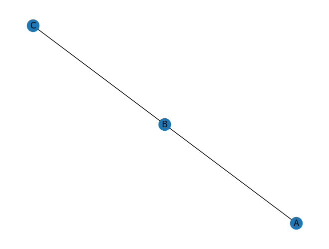

```
Number of nodes: 3
Number of edges: 2
Neighbors of node B: ['A', 'C']
```

```python
import networkx as nx
import matplotlib.pyplot as plt

# Create an empty graph
G = nx.Graph()  # Use nx.DiGraph() for a directed graph

# Add nodes
G.add_node("A")
G.add_node("B")
G.add_node("C")

# Add edges
G.add_edge("A", "B")
G.add_edge("B", "C")

# Draw the graph
nx.draw(G, with_labels=True)
plt.show()

# Number of nodes
print("Number of nodes:", G.number_of_nodes())

# Number of edges
print("Number of edges:", G.number_of_edges())

# Neighbors of a node
print("Neighbors of node B:", list(G.neighbors("B")))
```

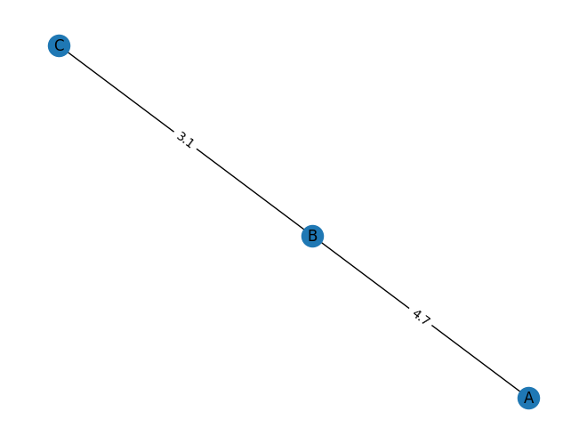

```python
# Add weighted edges
G.add_edge("A", "B", weight=4.7)
G.add_edge("B", "C", weight=3.1)

# Draw the graph with edge labels (weights)
pos = nx.spring_layout(G)  # positions for all nodes
nx.draw(G, pos, with_labels=True)
edge_labels = nx.get_edge_attributes(G, 'weight')
nx.draw_networkx_edge_labels(G, pos, edge_labels=edge_labels)
plt.show()
```

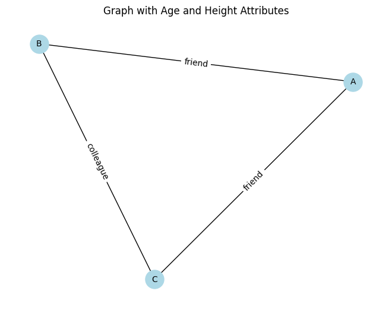

```
Node A Attributes: {'age': 30, 'height': 175}
Node B Age: 25
Node C Height: 180
```

```python
import networkx as nx
import matplotlib.pyplot as plt

# Create an empty graph
G = nx.Graph()

# Add nodes with 'age' and 'height' attributes
G.add_node("A", age=30, height=175)
G.add_node("B", age=25, height=160)
G.add_node("C", age=35, height=180)

# Add edges
G.add_edge("A", "B", relation="friend")
G.add_edge("B", "C", relation="colleague")
G.add_edge("C", "A", relation="friend")

# Draw the graph
pos = nx.spring_layout(G)
nx.draw(G, pos, with_labels=True, node_size=500, node_color="lightblue", font_size=10, font_color="black")
edge_labels = nx.get_edge_attributes(G, "relation")
nx.draw_networkx_edge_labels(G, pos, edge_labels=edge_labels)
plt.title("Graph with Age and Height Attributes")
plt.show()

# Access node, age, and height attributes
print("Node A Attributes:", G.nodes["A"])
print("Node B Age:", G.nodes["B"]["age"])
print("Node C Height:", G.nodes["C"]["height"])
```

```python
! pip install torch_geometric
```

## Graph Neural Networks (GNNs)

Graph Neural Networks (GNNs) are a class of neural networks designed to operate on data represented in graph form. They are particularly effective for learning from data where the relationships and interactions between entities are as important as the entities themselves. GNN represent a significant advancement in the field of deep learning, enabling the analysis and prediction of complex relationships in structured data.

### Key Characteristics of GNNs

- **Node Representation Learning:** GNNs learn to represent nodes (or vertices) in a way that captures both their features and their context within the graph.
- **Edge Representation:** They also take into account the edges (connections) between nodes, which can be directed, undirected, and sometimes weighted.
- **Message Passing:** GNNs use a technique called message passing, where nodes aggregate information from their neighbors, effectively allowing them to 'communicate' with each other.

### Applications of GNNs

GNNs are used in various domains, including:

- Social network analysis
- Recommendation systems
- Drug discovery
- Fraud detection
- Autonomous driving

### Types of GNNs

Several variants of GNNs exist, each suited to different kinds of graph data and tasks:

- **Graph Convolutional Networks (GCNs):** Ideal for semi-supervised learning on graph-structured data.
- **Graph Attention Networks (GATs):** They assign varying levels of importance to nodes' neighbors.
- **GraphSAGE:** Intended for inductive learning tasks on large graphs.

# Cora Dataset Summary

```python
from torch_geometric.datasets import Planetoid

# Load the Cora dataset
dataset = Planetoid(root=".", name="Cora")
data = dataset[0]  # Get the first (and only) graph

# Number of nodes
num_nodes = data.num_nodes

# Number of edges
num_edges = data.num_edges

# Each node's feature size
num_features = data.num_node_features

# Number of classes
num_classes = dataset.num_classes

# Checking if the graph is directed
is_directed = data.is_directed()

print(f"Number of nodes: {num_nodes}")
print(f"Number of edges: {num_edges}")
print(f"Number of features per node: {num_features}")
print(f"Number of classes: {num_classes}")
print(f"Is the graph directed: {is_directed}")
```

```
Number of nodes: 2708
Number of edges: 10556
Number of features per node: 1433
Number of classes: 7
Is the graph directed: False
```

```python
import pandas as pd
from torch_geometric.datasets import Planetoid

# Load the Cora dataset
dataset = Planetoid(root=".", name="Cora")
data = dataset[0]

# Convert node features to a DataFrame
features_df = pd.DataFrame(data.x.numpy())

# Add the labels as a new column
features_df['label'] = data.y.numpy()

# Display the DataFrame
print(features_df.head())
```

[output not shown]

```
     0    1    2    3    4    5    6    7    8    9  ...  1424  1425  1426  \
0  0.0  0.0  0.0  0.0  0.0  0.0  0.0  0.0  0.0  0.0  ...   0.0   0.0   0.0
1  0.0  0.0  0.0  0.0  0.0  0.0  0.0  0.0  0.0  0.0  ...   0.0   0.0   0.0
2  0.0  0.0  0.0  0.0  0.0  0.0  0.0  0.0  0.0  0.0  ...   0.0   0.0   0.0
3  0.0  0.0  0.0  0.0  0.0  0.0  0.0  0.0  0.0  0.0  ...   0.0   0.0   0.0
4  0.0  0.0  0.0  1.0  0.0  0.0  0.0  0.0  0.0  0.0  ...   0.0   0.0   0.0

   1427  1428  1429  1430  1431  1432  label
0   0.0   0.0   0.0   0.0   0.0   0.0      3
1   0.0   0.0   0.0   0.0   0.0   0.0      4
2   0.0   0.0   0.0   0.0   0.0   0.0      4
3   0.0   0.0   0.0   0.0   0.0   0.0      0
4   0.0   0.0   0.0   0.0   0.0   0.0      3

[5 rows x 1434 columns]
```

[output not shown]

Building a simple Neural Network with the Cora dataset without considering the edge relationships is a straightforward process. We will treat each node (representing a scientific paper) as an independent data point, ignoring the graph structure. This approach is akin to a typical classification task, where each node's features are used to predict its class.

```python
import torch
import torch.nn as nn
import torch.nn.functional as F
from torch_geometric.datasets import Planetoid
from torch_geometric.transforms import NormalizeFeatures
from torch.utils.data import DataLoader, TensorDataset

# Load the Cora dataset
dataset = Planetoid(root=".", name="Cora", transform=NormalizeFeatures())
data = dataset[0]

# Prepare the dataset
X = data.x
y = data.y

# Splitting the data into train and test sets
train_mask = data.train_mask
test_mask = data.test_mask

train_dataset = TensorDataset(X[train_mask], y[train_mask])
test_dataset = TensorDataset(X[test_mask], y[test_mask])

train_loader = DataLoader(train_dataset, batch_size=64, shuffle=True)
test_loader = DataLoader(test_dataset, batch_size=64, shuffle=False)

# Define a simple feedforward neural network
class VanillaNN(nn.Module):
    def __init__(self, input_dim, output_dim):
        super(VanillaNN, self).__init__()
        self.fc1 = nn.Linear(input_dim, 64)
        self.fc2 = nn.Linear(64, output_dim)

    def forward(self, x):
        x = F.relu(self.fc1(x))
        x = self.fc2(x)
        return F.log_softmax(x, dim=1)

# Instantiate the model
model = VanillaNN(dataset.num_node_features, dataset.num_classes)

# Loss and optimizer
criterion = nn.CrossEntropyLoss()
optimizer = torch.optim.Adam(model.parameters(), lr=0.01)

# Training the model
def train(epoch):
    model.train()
    for data, target in train_loader:
        optimizer.zero_grad()
        output = model(data)
        loss = criterion(output, target)
        loss.backward()
        optimizer.step()
    print(f'Epoch {epoch}: Training Loss: {loss.item():.4f}')

for epoch in range(1, 51):
    train(epoch)

# Testing the model
def test():
    model.eval()
    correct = 0
    with torch.no_grad():
        for data, target in test_loader:
            output = model(data)
            pred = output.max(1, keepdim=True)[1]
            correct += pred.eq(target.view_as(pred)).sum().item()

    print(f'Test Accuracy: {100. * correct / len(test_loader.dataset):.2f}%')

test()
```

```
Epoch 1: Training Loss: 1.9433
Epoch 2: Training Loss: 1.9024
Epoch 3: Training Loss: 1.9060
Epoch 4: Training Loss: 1.7912
Epoch 5: Training Loss: 1.7404
Epoch 6: Training Loss: 1.7154
Epoch 7: Training Loss: 1.5884
Epoch 8: Training Loss: 1.4271
Epoch 9: Training Loss: 1.2850
Epoch 10: Training Loss: 1.0851
Epoch 11: Training Loss: 0.9714
Epoch 12: Training Loss: 0.7689
Epoch 13: Training Loss: 0.6464
Epoch 14: Training Loss: 0.5399
Epoch 15: Training Loss: 0.4565
Epoch 16: Training Loss: 0.4163
Epoch 17: Training Loss: 0.2073
Epoch 18: Training Loss: 0.1723
Epoch 19: Training Loss: 0.1507
Epoch 20: Training Loss: 0.1274
Epoch 21: Training Loss: 0.1097
Epoch 22: Training Loss: 0.0757
Epoch 23: Training Loss: 0.0630
Epoch 24: Training Loss: 0.0839
Epoch 25: Training Loss: 0.0513
Epoch 26: Training Loss: 0.0419
Epoch 27: Training Loss: 0.0319
Epoch 28: Training Loss: 0.0334
Epoch 29: Training Loss: 0.0250
Epoch 30: Training Loss: 0.0240
Epoch 31: Training Loss: 0.0221
Epoch 32: Training Loss: 0.0195
Epoch 33: Training Loss: 0.0176
Epoch 34: Training Loss: 0.0181
Epoch 35: Training Loss: 0.0150
Epoch 36: Training Loss: 0.0126
Epoch 37: Training Loss: 0.0167
Epoch 38: Training Loss: 0.0153
Epoch 39: Training Loss: 0.0135
Epoch 40: Training Loss: 0.0130
Epoch 41: Training Loss: 0.0130
Epoch 42: Training Loss: 0.0132
Epoch 43: Training Loss: 0.0136
Epoch 44: Training Loss: 0.0082
Epoch 45: Training Loss: 0.0093
Epoch 46: Training Loss: 0.0086
Epoch 47: Training Loss: 0.0097
Epoch 48: Training Loss: 0.0090
Epoch 49: Training Loss: 0.0091
Epoch 50: Training Loss: 0.0078
Test Accuracy: 55.60%
```

## Adjacency Matrix Overview

The adjacency matrix is a key concept in graph theory, used to represent the connections between nodes in a graph. It's a square matrix that serves as a core data structure in both theoretical and computational analyses of graphs.

### Basic Definition

- **Nodes and Edges:** In a graph with *N* nodes, the edges represent connections between these nodes.
- **Matrix Representation:** The adjacency matrix for this graph is an *N x N* matrix, with each element indicating the presence or absence of an edge between two nodes.

### Elements of the Matrix

- **Element Value:** Typically contains 1s and 0s, where 1 indicates an edge between two nodes, and 0 indicates no edge.
- **Diagonal Elements:** These elements usually have a value of 0, representing that nodes do not connect to themselves.

### Variations

- **Undirected Graphs:** The adjacency matrix is symmetric, indicating mutual connections.
- **Directed Graphs:** The matrix is not necessarily symmetric, reflecting the direction of connections.
- **Weighted Graphs:** Contains edge weights instead of just 1s, representing the strength or cost of connections.

### Example

Consider a graph with three nodes A, B, and C, where A is connected to B, and B to C. The adjacency matrix would be:

```
  A B C
A 0 1 0
B 1 0 1
C 0 1 0
```

### Applications

Adjacency matrices are used in graph algorithms, network analysis, social network modeling, and as a fundamental tool in GNNs among other applications in computer science and mathematics. In summary, the adjacency matrix is a versatile tool for representing and analyzing graphs, with applications ranging from mathematics to computer science and machine learning.

## Building a Neural Network with the Cora Dataset Using Adjacency Matrix

When building a neural network with the Cora dataset, incorporating the graph's adjacency matrix is essential to account for the relationships between nodes. Unlike approaches that treat each node as an independent data point, this method leverages the connections (edges) represented by the adjacency matrix to enhance prediction accuracy in graph-based learning contexts.

### Importance of the Adjacency Matrix

The adjacency matrix is crucial in graph-based neural network models as it captures the essential structure of the graph:

- Each element in the matrix indicates whether a pair of nodes is connected, thereby representing the edges in the graph.
- This matrix is key to understanding the relationships and interactions between nodes, which are vital in tasks like node classification.

### Advantages of Utilizing the Adjacency Matrix

Integrating the adjacency matrix into the neural network model provides several advantages:

- It allows the model to consider not just the features of individual nodes, but also how nodes are interconnected.
- This approach is particularly beneficial for tasks where the node's context within the graph (its connections to other nodes) significantly influences its properties or classification.

Overall, using the adjacency matrix in neural network models with the Cora dataset (or similar graph-structured data) facilitates a more nuanced and context-aware analysis, leading to potentially more accurate and insightful results.

```python
import torch
import torch.nn as nn
import torch.nn.functional as F
from torch_geometric.datasets import Planetoid
from torch_geometric.transforms import NormalizeFeatures
from torch_geometric.utils import to_dense_adj
from torch.utils.data import DataLoader, TensorDataset

# Load the Cora dataset
dataset = Planetoid(root=".", name="Cora", transform=NormalizeFeatures())
data = dataset[0]

# Convert the edge index to an adjacency matrix
adjacency_matrix = to_dense_adj(data.edge_index)[0]

# Feature aggregation using the adjacency matrix
aggregated_features = torch.mm(adjacency_matrix, data.x)

# Prepare the dataset
X = aggregated_features
y = data.y

# Splitting the data into train and test sets
train_mask = data.train_mask
test_mask = data.test_mask

train_dataset = TensorDataset(X[train_mask], y[train_mask])
test_dataset = TensorDataset(X[test_mask], y[test_mask])

train_loader = DataLoader(train_dataset, batch_size=64, shuffle=True)
test_loader = DataLoader(test_dataset, batch_size=64, shuffle=False)

# Define a simple feedforward neural network
class VanillaNN(nn.Module):
    def __init__(self, input_dim, output_dim):
        super(VanillaNN, self).__init__()
        self.fc1 = nn.Linear(input_dim, 64)
        self.fc2 = nn.Linear(64, output_dim)

    def forward(self, x):
        x = F.relu(self.fc1(x))
        x = self.fc2(x)
        return F.log_softmax(x, dim=1)

# Instantiate the model
model = VanillaNN(dataset.num_node_features, dataset.num_classes)

# Loss and optimizer
criterion = nn.CrossEntropyLoss()
optimizer = torch.optim.Adam(model.parameters(), lr=0.01)

# Training the model
def train(epoch):
    model.train()
    for data, target in train_loader:
        optimizer.zero_grad()
        output = model(data)
        loss = criterion(output, target)
        loss.backward()
        optimizer.step()
        print(f'Epoch {epoch}: Training Loss: {loss.item():.4f}')

for epoch in range(1, 51):
    train(epoch)

# Testing the model
def test():
    model.eval()
    correct = 0
    with torch.no_grad():
        for data, target in test_loader:
            output = model(data)
            pred = output.max(1, keepdim=True)[1]
            correct += pred.eq(target.view_as(pred)).sum().item()

    print(f'Test Accuracy: {100. * correct / len(test_loader.dataset):.2f}%')

test()
```

## Training the Cora Dataset with Graph Convolutional Operations

Training the Cora dataset using graph convolutional operations involves utilizing the specialized techniques of GNNs, specifically Graph Convolutional Networks (GCNs), to process and learn from graph-structured data.

### Understanding Graph Convolutional Networks

Graph Convolutional Networks are a type of GNN tailored for processing data represented in graph form. They are particularly effective for tasks like node classification in graphs:

- **Graph Convolution:** This operation extends the concept of convolution from traditional neural networks to graph data, allowing the model to aggregate and transform feature information from a node's neighbors.
- **Message Passing:** In GCNs, nodes 'communicate' with each other through a process called message passing, where each node updates its features based on its own features and those of its neighbors.

```python
import torch
import torch.nn.functional as F
from torch_geometric.nn import GCNConv
from torch_geometric.datasets import Planetoid
from torch_geometric.transforms import NormalizeFeatures

# Load the Cora dataset
dataset = Planetoid(root=".", name="Cora", transform=NormalizeFeatures())
data = dataset[0]  # The graph data object contains the data of the Cora dataset

# Define the GCN model
class GCN(torch.nn.Module):
    def __init__(self, input_dim, hidden_dim, output_dim):
        super(GCN, self).__init__()
        self.conv1 = GCNConv(input_dim, hidden_dim)  # First GCN layer
        self.conv2 = GCNConv(hidden_dim, output_dim)  # Second GCN layer

    def forward(self, data):
        x, edge_index = data.x, data.edge_index  # Extract node features and edge indices

        # Forward pass through the first GCN layer
        x = self.conv1(x, edge_index)
        x = F.relu(x)  # Apply ReLU activation function
        x = F.dropout(x, training=self.training)  # Apply dropout for regularization
        x = self.conv2(x, edge_index)  # Forward pass through the second GCN layer

        return F.log_softmax(x, dim=1)  # Apply log softmax to output for classification

# Instantiate the model
model = GCN(dataset.num_node_features, 16, dataset.num_classes)  # Initialize the GCN model

# Loss and optimizer
criterion = torch.nn.CrossEntropyLoss()  # Define the loss function
optimizer = torch.optim.Adam(model.parameters(), lr=0.01)  # Define the optimizer

# Training the model
def train(data):
    model.train()  # Set the model to training mode
    optimizer.zero_grad()  # Clear gradients
    out = model(data)  # Forward pass
    loss = criterion(out[data.train_mask], data.y[data.train_mask])  # Compute loss
    loss.backward()  # Backpropagate the loss
    optimizer.step()  # Update model parameters
    return loss.item()  # Return the loss value


def test_model(data):
    model.eval()  # Set the model to evaluation mode
    test_loss = 0
    correct = 0
    total = 0

    with torch.no_grad():  # No gradients needed for evaluation
        for mask_type in ['test_mask']:  # We need only the test mask here
            mask = getattr(data, mask_type)
            logits = model(data)[mask]  # Get predictions for test data
            labels = data.y[mask]
            test_loss += criterion(logits, labels).item()  # Sum up batch loss
            _, predicted = torch.max(logits, 1)
            total += labels.size(0)
            correct += predicted.eq(labels).sum().item()

    test_loss /= total  # Average loss
    test_accuracy = 100. * correct / total  # Calculate accuracy
    test_rmse = torch.sqrt(torch.tensor(test_loss))  # Calculate RMSE

    return test_loss, test_accuracy, test_rmse.item()  # Return loss, accuracy, and RMSE

# Main training loop
for epoch in range(1, 201):
    train_loss = train(data)  # Train the model for one epoch
    test_loss, test_acc, test_rmse = test_model(data)  # Test the model
    # Print epoch number, training loss, test loss, test accuracy, and test RMSE
    print(f'Epoch: {epoch:03d}, '
          f'Train Loss: {train_loss:.4f}, '
          f'Test Loss: {test_loss:.4f}, '
          f'Test Acc: {test_acc:.4f}, '
          f'Test RMSE: {test_rmse:.4f}')
```

## Training the Cora Dataset with Graph Attention Mechanisms

Training the Cora dataset using graph attention mechanisms leverages the advanced capabilities of Graph Neural Networks (GNNs), specifically Graph Attention Networks (GATs), to process and learn from graph-structured data. GATs enhance the traditional message-passing framework by introducing learnable attention coefficients, which prioritize the most relevant neighbors for each node.

### Understanding Graph Attention Networks

Graph Attention Networks are a type of GNN designed to address the limitations of conventional graph convolutional methods by incorporating attention mechanisms. These models are highly effective for tasks like node classification in graphs:

- **Graph Attention:** This operation introduces an attention mechanism that assigns learnable weights to edges, allowing the model to focus more on important neighbors while ignoring less relevant ones.
- **Multi-Head Attention:** GATs often use multi-head attention, where multiple attention mechanisms operate in parallel to capture diverse relationships in the graph.
- **Message Passing with Attention:** Nodes update their features by aggregating information from their neighbors, weighted by the attention coefficients. This process ensures that the most critical relationships are emphasized during training.

```python
import torch
import torch.nn.functional as F
from torch_geometric.nn import GATConv
from torch_geometric.datasets import Planetoid
from torch_geometric.transforms import NormalizeFeatures

# Load the Cora dataset
dataset = Planetoid(root=".", name="Cora", transform=NormalizeFeatures())
data = dataset[0]  # The graph data object contains the data of the Cora dataset

# Define the GAT model
class GAT(torch.nn.Module):
    def __init__(self, input_dim, hidden_dim, output_dim, heads=8):
        super(GAT, self).__init__()
        # First GAT layer with multi-head attention
        self.conv1 = GATConv(input_dim, hidden_dim, heads=heads, dropout=0.6)
        # Second GAT layer with a single output head
        self.conv2 = GATConv(hidden_dim * heads, output_dim, heads=1, concat=False, dropout=0.6)

    def forward(self, data):
        x, edge_index = data.x, data.edge_index  # Extract node features and edge indices

        # Forward pass through the first GAT layer
        x = self.conv1(x, edge_index)
        x = F.elu(x)  # Apply ELU activation function
        x = F.dropout(x, p=0.6, training=self.training)  # Apply dropout for regularization
        x = self.conv2(x, edge_index)  # Forward pass through the second GAT layer

        return F.log_softmax(x, dim=1)  # Apply log softmax to output for classification

# Instantiate the model
model = GAT(dataset.num_node_features, 8, dataset.num_classes, heads=8)  # Initialize the GAT model

# Loss and optimizer
criterion = torch.nn.CrossEntropyLoss()  # Define the loss function
optimizer = torch.optim.Adam(model.parameters(), lr=0.005, weight_decay=5e-4)  # Define the optimizer

# Training the model
def train(data):
    model.train()  # Set the model to training mode
    optimizer.zero_grad()  # Clear gradients
    out = model(data)  # Forward pass
    loss = criterion(out[data.train_mask], data.y[data.train_mask])  # Compute loss
    loss.backward()  # Backpropagate the loss
    optimizer.step()  # Update model parameters
    return loss.item()  # Return the loss value


def test_model(data):
    model.eval()  # Set the model to evaluation mode
    correct = 0
    with torch.no_grad():  # No gradients needed for evaluation
        logits = model(data)
        for mask_type in ['test_mask']:  # We need only the test mask here
            mask = getattr(data, mask_type)
            preds = logits[mask].max(1)[1]  # Get predictions
            correct += preds.eq(data.y[mask]).sum().item()

    accuracy = correct / data.test_mask.sum().item()  # Calculate accuracy
    return accuracy

# Main training loop
for epoch in range(1, 201):
    train_loss = train(data)  # Train the model for one epoch
    test_acc = test_model(data)  # Test the model
    # Print epoch number, training loss, and test accuracy
    print(f'Epoch: {epoch:03d}, '
          f'Train Loss: {train_loss:.4f}, '
          f'Test Acc: {test_acc:.4f}')
```

## Training the Cora Dataset with GraphSAGE

Training the Cora dataset using GraphSAGE (Graph Sample and Aggregate) utilizes the unique inductive capabilities of Graph Neural Networks (GNNs) to process graph-structured data. GraphSAGE focuses on generalizing to unseen nodes or graphs by learning a function to aggregate and transform information from a node's neighborhood.

### Understanding GraphSAGE

GraphSAGE is a type of GNN specifically designed to address scalability and inductive learning challenges in large or dynamic graphs. It achieves this through a flexible and efficient message-passing framework:

- **Neighborhood Sampling:** GraphSAGE samples a fixed-size set of neighbors for each node, making it computationally efficient and scalable for large graphs.
- **Aggregation Functions:** GraphSAGE provides flexibility in how neighbor features are aggregated, with options such as mean, max, LSTM-based, or pooling aggregators. This adaptability allows the model to learn meaningful representations for diverse graph structures.
- **Inductive Learning:** Unlike traditional GNNs, GraphSAGE learns a mapping function that can be applied to nodes in previously unseen graphs, making it highly suitable for dynamic or expanding datasets.

```python
import torch
import torch.nn.functional as F
from torch_geometric.nn import SAGEConv
from torch_geometric.datasets import Planetoid
from torch_geometric.transforms import NormalizeFeatures

# Load the Cora dataset
dataset = Planetoid(root=".", name="Cora", transform=NormalizeFeatures())
data = dataset[0]  # The graph data object contains the data of the Cora dataset

# Define the GraphSAGE model
class GraphSAGE(torch.nn.Module):
    def __init__(self, input_dim, hidden_dim, output_dim):
        super(GraphSAGE, self).__init__()
        self.conv1 = SAGEConv(input_dim, hidden_dim)  # First GraphSAGE layer
        self.conv2 = SAGEConv(hidden_dim, output_dim)  # Second GraphSAGE layer

    def forward(self, data):
        x, edge_index = data.x, data.edge_index  # Extract node features and edge indices

        # Forward pass through the first GraphSAGE layer
        x = self.conv1(x, edge_index)
        x = F.relu(x)  # Apply ReLU activation function
        x = F.dropout(x, p=0.5, training=self.training)  # Apply dropout for regularization
        x = self.conv2(x, edge_index)  # Forward pass through the second GraphSAGE layer

        return F.log_softmax(x, dim=1)  # Apply log softmax to output for classification

# Instantiate the model
model = GraphSAGE(dataset.num_node_features, 16, dataset.num_classes)  # Initialize the GraphSAGE model

# Loss and optimizer
criterion = torch.nn.CrossEntropyLoss()  # Define the loss function
optimizer = torch.optim.Adam(model.parameters(), lr=0.01, weight_decay=5e-4)  # Define the optimizer

# Training function
def train(data):
    model.train()  # Set the model to training mode
    optimizer.zero_grad()  # Clear gradients
    out = model(data)  # Forward pass
    loss = criterion(out[data.train_mask], data.y[data.train_mask])  # Compute loss
    loss.backward()  # Backpropagate the loss
    optimizer.step()  # Update model parameters
    return loss.item()  # Return the loss value

# Test function
def test(data):
    model.eval()  # Set the model to evaluation mode
    logits = model(data)  # Get model predictions
    masks = ['train_mask', 'val_mask', 'test_mask']  # Define masks
    accuracies = {}

    with torch.no_grad():  # No gradients needed for evaluation
        for mask_type in masks:
            mask = getattr(data, mask_type)  # Get the appropriate mask
            preds = logits[mask].argmax(dim=1)  # Get predictions for nodes
            correct = preds.eq(data.y[mask]).sum().item()  # Count correct predictions
            accuracies[mask_type] = correct / mask.sum().item()  # Compute accuracy

    return accuracies

# Main training loop
for epoch in range(1, 201):
    train_loss = train(data)  # Train the model for one epoch
    accuracies = test(data)  # Test the model on train, validation, and test sets

    # Print epoch number, training loss, and accuracies
    print(f'Epoch: {epoch:03d}, '
          f'Train Loss: {train_loss:.4f}, '
          f'Train Acc: {accuracies["train_mask"]:.4f}, '
          f'Val Acc: {accuracies["val_mask"]:.4f}, '
          f'Test Acc: {accuracies["test_mask"]:.4f}')
```